# Bellabeat Case Study

Kathryn Ference

10/28/2021

This is an analysis of a 2016 study of FitBit fitness tracker data conducted by Fitabase, a San Diego-based research firm. The data was generated by 33 respondents to a distributed study between March 12, 2016 and May 12, 2016.

This analysis will look at how this information can help Bellabeat, a brand that produces smart devices targeted to promote women’s overall health and well-being. With this analysis, we will explore ways to optimize the Bellabeat app, which connects to Bellabeat’s devices and provides users with health data related to their activity, sleep, stress, menstrual cycle, and mindfulness habits. We are especially interested in how this app data can be optimized in relation to Bellabeat’s brand new smart device, Ivy, released in January 2021.

## Correlation in Daily Activities

First, we will look at the average daily activities logged per person over time, and see if we find correlations between these variables.

To do this, take the dailyActivity_merged sheet, remove any NULL values, and remove the date column. There were many values logged over time for each ID number, so to see the average of daily activities, steps, calories, etc, for each person during this time period, average each column by ID number:

```r
load("~/no_date_df.RData")
mean_df <- aggregate(.~Id, no_date_df, mean)
```

To see correlations between variables, we calculate the correlations in the data frame using the Pearson method. In the table, correlation coefficients are displayed between -1 (a perfect negative correlation) and 1 (a perfect positive correlation). Correlations are generally significant below -.6 or above .6.

```r
activityCorrs <- cor(mean_df, method="pearson")
print(activityCorrs)
```

```
##                                    Id   TotalSteps TotalDistance
## Id                        1.000000000  0.240109390   0.315943982
## TotalSteps                0.240109390  1.000000000   0.984909841
## TotalDistance             0.315943982  0.984909841   1.000000000
## TrackerDistance           0.312361103  0.983708932   0.999622834
## LoggedActivitiesDistance  0.289885659  0.206688202   0.200794106
## VeryActiveDistance        0.431212936  0.784653059   0.819969115
## ModeratelyActiveDistance  0.038390840  0.492113405   0.445104005
## LightActiveDistance      -0.005258013  0.723953947   0.718515526
## SedentaryActiveDistance  -0.055313732 -0.005839943   0.003507061
## VeryActiveMinutes         0.406765080  0.701374580   0.727350164
## FairlyActiveMinutes       0.081580951  0.477993234   0.436456443
## LightlyActiveMinutes     -0.167886962  0.510720403   0.452237458
## SedentaryMinutes         -0.019015481 -0.385461674  -0.320322157
## Calories                  0.476970080  0.436043228   0.546319734
##                          TrackerDistance LoggedActivitiesDistance
## Id                           0.312361103               0.28988566
## TotalSteps                   0.983708932               0.20668820
## TotalDistance                0.999622834               0.20079411
## TrackerDistance              1.000000000               0.17709533
## LoggedActivitiesDistance     0.177095332               1.00000000
## VeryActiveDistance           0.821133716               0.13072864
## ModeratelyActiveDistance     0.444926897               0.06472932
## LightActiveDistance          0.715889841               0.21668862
## SedentaryActiveDistance      0.003651034              -0.05224457
## VeryActiveMinutes            0.728404579               0.20899190
## FairlyActiveMinutes          0.436919313               0.03029609
## LightlyActiveMinutes         0.447930008               0.15577112
## SedentaryMinutes            -0.321925053              -0.09424594
## Calories                     0.546944472               0.23339581
##                          VeryActiveDistance ModeratelyActiveDistance
## Id                               0.43121294               0.03839084
## TotalSteps                       0.78465306               0.49211340
## TotalDistance                    0.81996912               0.44510400
## TrackerDistance                  0.82113372               0.44492690
## LoggedActivitiesDistance         0.13072864               0.06472932
## VeryActiveDistance               1.00000000               0.16402040
## ModeratelyActiveDistance         0.16402040               1.00000000
## LightActiveDistance              0.24791924               0.26265132
## SedentaryActiveDistance         -0.04931726              -0.18768496
```

[output cut: 35 more lines]

```
##                          LightlyActiveMinutes SedentaryMinutes    Calories
## Id                               -0.167886962      -0.01901548  0.47697008
## TotalSteps                        0.510720403      -0.38546167  0.43604323
## TotalDistance                     0.452237458      -0.32032216  0.54631973
## TrackerDistance                   0.447930008      -0.32192505  0.54694447
## LoggedActivitiesDistance          0.155771118      -0.09424594  0.23339581
## VeryActiveDistance                0.027590062      -0.04163279  0.51161933
## ModeratelyActiveDistance          0.115434249      -0.39824794  0.06197865
## LightActiveDistance               0.833552206      -0.44636247  0.35110003
## SedentaryActiveDistance           0.289466738       0.23094712 -0.02632543
## VeryActiveMinutes                 0.003218503      -0.20291582  0.62996619
## FairlyActiveMinutes               0.030150822      -0.38575600  0.15767991
## LightlyActiveMinutes              1.000000000      -0.44035895 -0.00407536
## SedentaryMinutes                 -0.440358952       1.00000000 -0.07699961
## Calories                         -0.004075360      -0.07699961  1.00000000
```

As we are comparing a number of variables, the table is very difficult to look at. In order to make it easier to view, we can plot this correlation table to better see relationships between the variables:

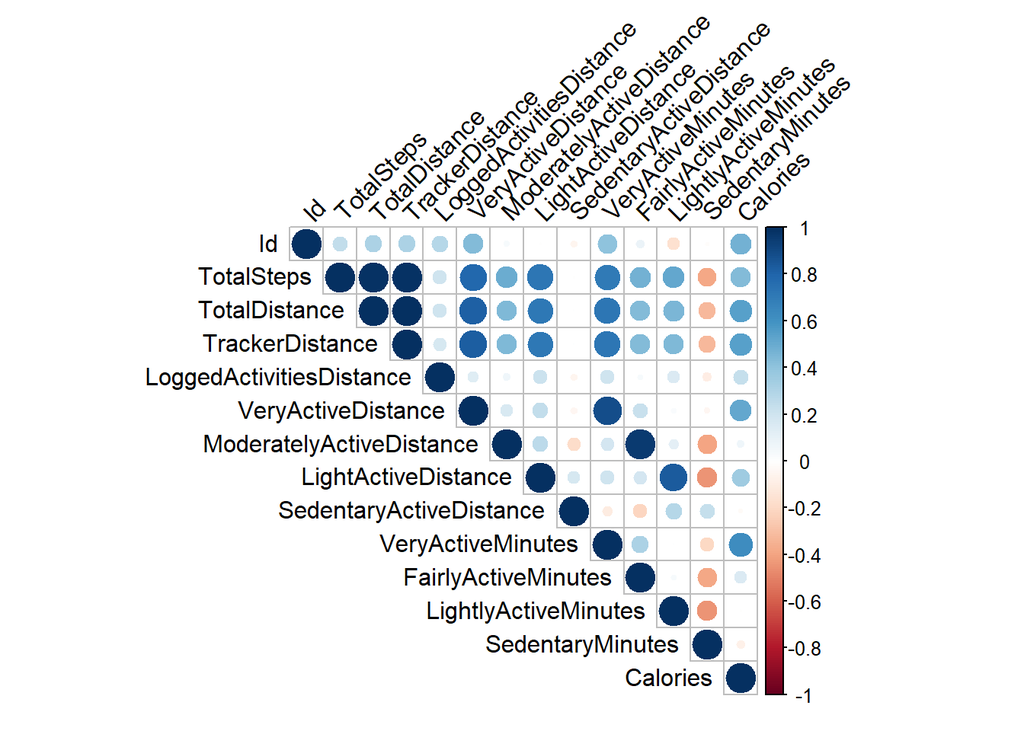

```r
library(corrplot)
corrplot(activityCorrs,type="upper",order="original",tl.col="black",tl.srt=45)
```

Obviously there are strong correlations between steps and distance (.98), as they essentially measure the same thing. There are also strong correlations between distance traveled at various intensities and minutes spent at those various intensities, which also is to be expected. (If one spends time going distance at a very active pace, it is to be expected that the minutes spent doing so will be very active minutes, for example.)

There is a negative correlation between Sedentary minutes and almost every other variable–the more time spent being sedentary, the fewer total steps, total distance, and active minutes a person will get in a day.

However, the ‘Calories’ variable produces some interesting and perhaps unexpected correlations. There is no correlation between Sedentary Minutes and calories (as one might expect), and the correlation between Calories and Total Steps is also surprisingly weak–the correlation coefficient is only .43. Instead, the strongest correlation between Calories and activity level appears to be ‘Very Active Minutes’. This would suggest that those users who are hoping to maximize their calories burned should be maximizing active minutes rather than distance or steps.

Considering this, for those smart device wearers whose goal is to lose weight, it might be best to include app reminders and other cues that encourage people to engage in high energy exercise rather than to maximize total number of steps.

## Correlation between Activity and Sleep

There is a common belief that exercise during the day an improve sleep for many people. However, our data did not show that activity levels had any significant impact on total minutes asleep or total time in bed.

We found this by averaging the sleep minutes and time in bed for each user and concatenating this with the activity sheet by Id number. The resulting correlation plot was the following:

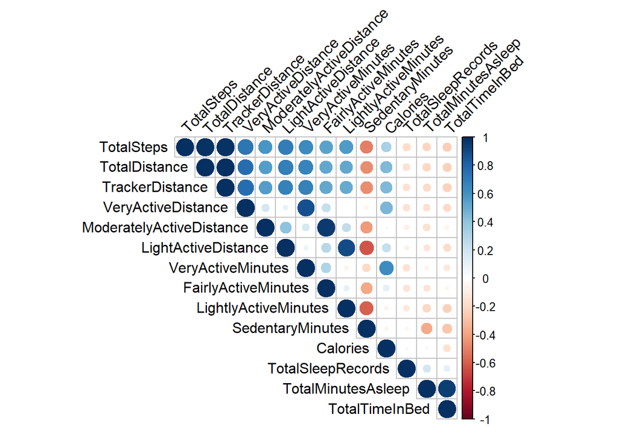

Although there is a very slight negative correlation, these numbers were not statistically significant–essentially, no relationship exists. However, number of minutes asleep and total time in bed does not give us information on the quality of sleep users had, so more information on the quality of individuals’ sleep.

Theoretically, we could get a sense of the quality of each individuals’ sleep through the minuteSleep_merged dataset, as this set tracks the quality of each persons’ sleep over the course of each night using the values 1 for ‘awake’, 2 for ‘restless’, and 3 for ‘awake’. More 2s and 3s should indicate more restless, and therefore poorer quality, sleep.

However, the users’ nightly tracking of sleep is very inconsistent. Some users sleep with their devices every night, providing very high quality data. Others, however, rarely use the feature. Here are the number of nights each user logged their sleep over the course of the study:

```r
load("~/minute_sleep_table.RData")
print(minute_sleep_table)
```

```
##            Id Freq
## 1  1503960366   25
## 2  1644430081    5
## 3  1844505072    5
## 4  1927972279    8
## 5  2026352035   32
## 6  2320127002    1
## 7  2347167796   18
## 8  3977333714   28
## 9  4020332650   11
## 10 4319703577   29
## 11 4388161847   26
## 12 4445114986   28
## 13 4558609924    8
## 14 4702921684   31
## 15 5553957443   32
## 16 5577150313   28
## 17 6117666160   21
## 18 6775888955    3
## 19 6962181067   31
## 20 7007744171    2
## 21 7086361926   27
## 22 8053475328    3
## 23 8378563200   32
## 24 8792009665   15
```

This table only includes the users who did track any sleep data over the course of the study–9 of the users had no sleep data recorded at all during the course of the study. This means 27% of the consumers in this study did not access or make use of this feature at all!

This is worth noting. Bellabeat is a company that places utmost focus on lifestyle and overall wellness. Sleep is a key part of the daily wellness score users are given. If 27% of users are not even accessing the the sleep tracking feature, this could impact the ability of the app to provide relevant data on wellness to users.

Are there particular users who are more or less likely to track their sleep data? We will be able to determine this using a measure called k-means clustering.

## Correlation between Activity and Heart Rate

Unlike the correlation between activity and sleep, our data did show some correlation between daily steps, activity levels and median heart rate.

To see the average heart rates, we uploaded the heartrate_seconds_merged data set, then aggregated by Id to calculate the median heart rate per user. Median is a better measure here than mean, because we are interested in looking at resting heart rate for each user. If a user is exercising regularly, their heart rate may be higher, but even the most ardent athletes will be at rest most of the time. Therefore, the median heart rate is much more likely to be close to the user’s resting heart rate.

Then, we can merge this heart rate date with the activity data by user Id.

```r
load("~/heartrate.RData")
load("~/mean_activity_df.RData")
heartrate_median <- aggregate(Value ~ Id, heartrate, median)
heartrate_merge <- merge(mean_activity_df, heartrate_median, by="Id")
```

Just to note, there was only heart rate data available for 14 of the users, so we should avoid drawing too many conclusions about the full data set from this subset. Unlike sleep, heart rate is not something manually entered by the user, so it is very likely that the other 19 participants in the study were using Fitbit trackers that did not have heart rate monitors. This data is from 2016, when heart rate monitoring was less common in FitBit trackers; if this study were to be replicated in 2021, this percentage would no doubt be higher. That is a limitation of this data set.

Among the 42% of users whose smart devices featured heart rate monitors, we can see some interesting trends. First, there is somewhat of a correlation between activity rates and resting heart rate in these users:

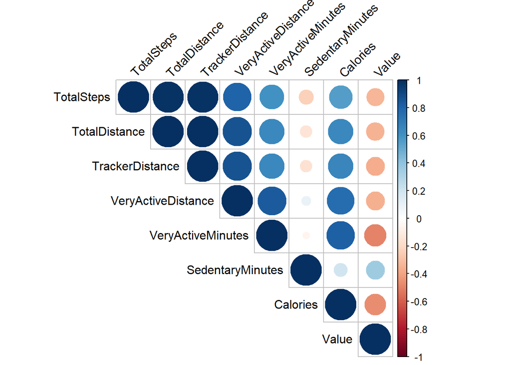

```r
heartrate_merge <- heartrate_merge[ -c(1, 5, 7:9, 11:12)]
heartrateMatrix <- cor(heartrate_merge, method="pearson")
heartratePlot <- corrplot(heartrateMatrix,type="upper",order="original",tl.col="black",tl.srt=45)
```

Much like with the correlations between activity rate and calories burned, the strongest correlation between activity and resting heart rate was among those users who had the most ‘very active minutes’ during the day, although all categories seemed to have some affect. More sedentary minutes means a slightly higher resting heart rate.

## K-Means Clustering

K-means clustering, put simply, is a method that attempts to divide observations into smaller groups that have variables in common. Each observation belongs to the cluster with the nearest mean, which serves as the prototype of the cluster. This process can give us better insight into the types of people using smart apps and what these groups may have in common.

The first step to k means clustering is to figure out the number of groups, k, that the dataset can be divided into. There are a few different ways to do this. Three of them are an elbow plot, a silhouette plot, and a gap statistic.

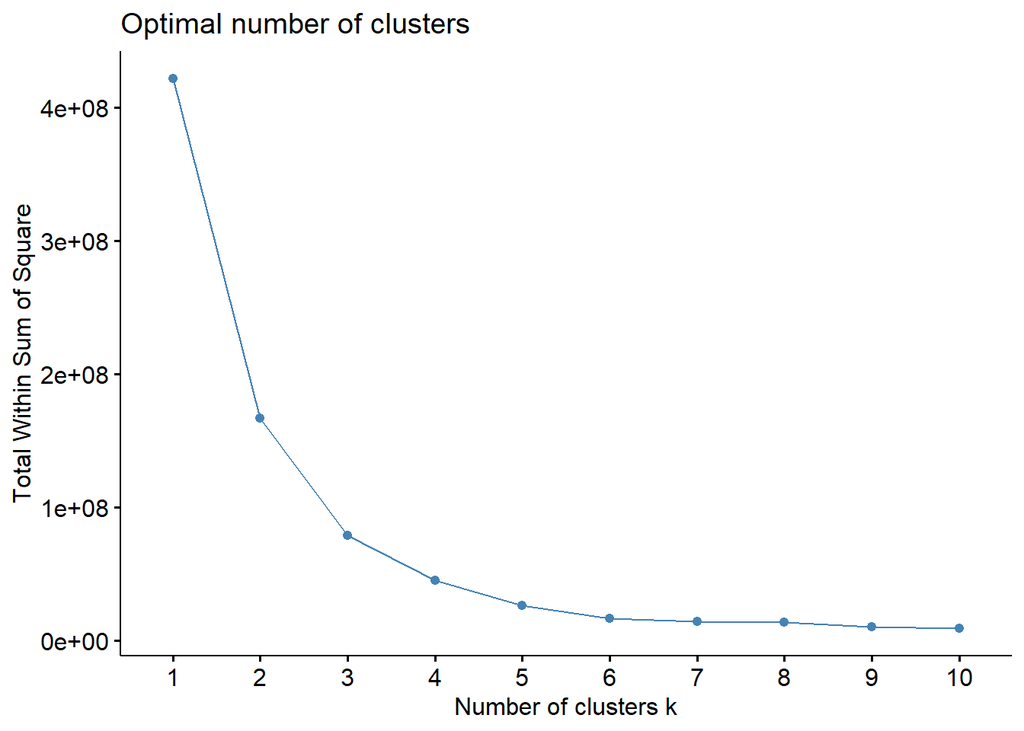

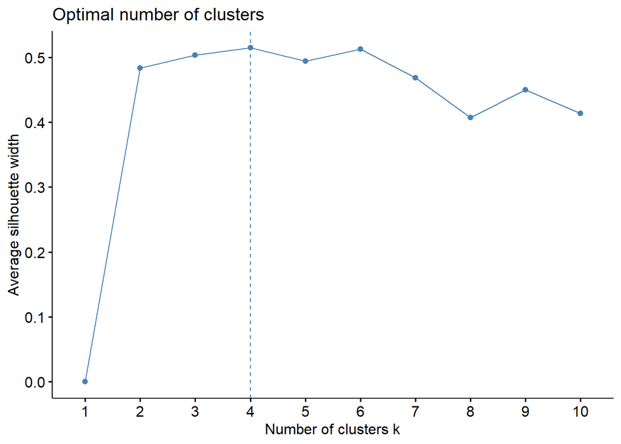

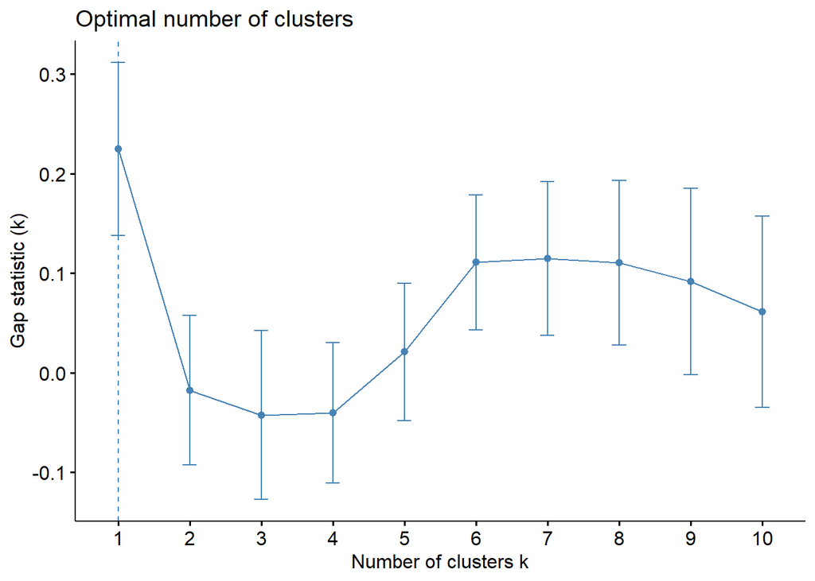

```r
final <- kmeans(kmeans_df, 4)
print(final)
```

```
## K-means clustering with 4 clusters of sizes 7, 14, 7, 5
##
## Cluster means:
##        Freq TotalSteps TotalDistance TrackerDistance VeryActiveDistance
## 1  8.714286   5256.272      3.657930        3.657930          0.5611017
## 2 18.714286   8128.045      5.791830        5.787084          1.1960958
## 3 12.000000  12487.519      9.215364        9.152561          3.7402304
## 4  8.400000   2027.367      1.393357        1.393357          0.1961020
##   ModeratelyActiveDistance LightActiveDistance VeryActiveMinutes
## 1                0.2048895            2.879846          5.825267
## 2                0.6877391            3.773498         22.248305
## 3                0.9524576            4.458581         42.760794
## 4                0.1305013            1.055578          3.722136
##   FairlyActiveMinutes LightlyActiveMinutes SedentaryMinutes Calories
## 1            4.285141            180.68034        1099.2592 1899.389
## 2           16.100528            224.61491         881.0585 2425.339
## 3           22.274713            221.13097         974.4528 2549.141
## 4            5.252306             72.58294        1224.2392 2045.235
##
## Clustering vector:
##  [1] 3 1 2 4 4 3 1 1 2 2 2 3 4 1 2 3 1 2 2 2 2 2 1 4 2 3 2 3 1 2 2 4 3
##
## Within cluster sum of squares by cluster:
## [1]  5788515 17251506 28622669  2285939
##  (between_SS / total_SS =  87.2 %)
##
## Available components:
##
## [1] "cluster"      "centers"      "totss"        "withinss"     "tot.withinss"
## [6] "betweenss"    "size"         "iter"         "ifault"
```

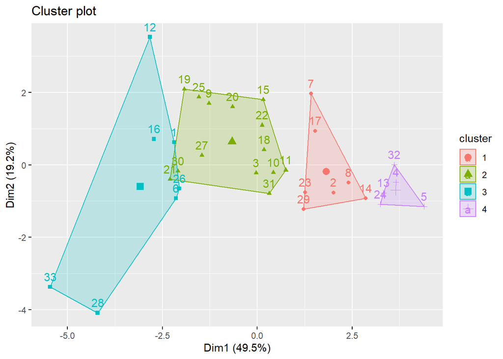

## Types of smart device users

The users in the data set can be divided into 4 basic types in their use of their smart devices.

### Group 2

This group is the second-best target for Bellabeat’s marketing strategy. Although they are not as active now, they are lightly active and will track some of their nightly sleep. Although gender was not included in this data set, this group had the lowest calories burned per day even though they were not the least active group. Calories burned are highly correlated to body mass, so this group is likely to be smaller in stature, which means that this group may contain more women. Since women are Bellabeat’s target demographic, this also makes them more likely to be interested in the company’s products.

### Group 4

Interestingly, even though they were significantly more sedentary than Group 2, they burned more calories than Group 2. This would suggest that there are other variables at play here that are not available with this data set–possibly a size or even potentially a gender difference between the two groups, as larger people are more likely to burn more calories regardless of daily activity.

This group is the least likely to be a target consumer of Bellabeat’s products.

## Conclusions

In this analysis of smart device usage, we have explored the ways that users’ activities affect their calories burned, sleep quantity, and resting heart rate. Science has known for some time that that these variables are correlated, but what is most useful about this data is that the smart device can track and demonstrate these correlations in real time to the user.

In order to help users see the most improvement in their calories burned and resting heart rate, the Bellabeat app should encourage users to exercise at a very high level of activity as much as possible. If the company is able to demonstrate that users are able to make real improvements in these areas over time by using the feedback data from the app, the marketing department can use these results in their campaigns. Proof that Bellabeat can demonstrate real results over time will be of particular interest to users who are seeking to improve their health.

At the time of this survey, only 42% of users had devices that tracked heart rate monitoring data. Among Group 3, the group that best resembles Bellabeat’s target audience, this number was even smaller, at 38%. This could suggest that heart rate monitoring is less important to this group. However, as previously mentioned, this number would likely be higher in a study conducted in 2021 as heart rate monitoring has proliferated in more and more devices. Bellabeat itself is relatively new to heart rate monitoring in its smart devices; only their newest device, Ivy, has this feature, and it was released in 2021.

Bellabeat’s app provides a wealth of data to the user, including resting heart rate, respiratory rate, and cardiac coherence, and helps users understand their stress levels, wellness, and readiness to face the day. Bellabeat’s app also tracks activity to add more movement to their day. The app could be even better if the app could combine activity and wellness to help users understand how their daily activity affects their resting heart rate, sleep, and other factors. We can understand this relationship using users’ data and correlation between variables.

Through this data, we were also able to segment the users into those more or less likely to be similar to Bellabeat’s market segment. Understanding how device use relates to market segmentation could improve Bellabeat’s reach to smart device users who are currently using devices from other brands but might be more interested in Bellabeat’s offerings.

Additional data could certainly expand on these findings. A more recent study would help us understand how smart device usage has evolved over time. Market research surveys could provide eye-opening insight into why device users behave the way they do, which would add valuable insight to the thinking behind the numbers. And, as women are an explicit demographic of Bellabeat’s products, data about how women use their devices would be extremely helpful in understanding what this market segments needs and wants from the smart devices they use.